# Stroop Effect Assignment

```python
import pandas as pd
import matplotlib.pyplot as plt
import numpy as np
import matplotlib
```

Background Information In a Stroop task, participants are presented with a list of words, with each word displayed in a color of ink. The participant’s task is to say out loud the color of the ink in which the word is printed. The task has two conditions: a congruent words condition, and an incongruent words condition. In the congruent words condition, the words being displayed are color words whose names match the colors in which they are printed: for example RED, BLUE. In the incongruent words condition, the words displayed are color words whose names do not match the colors in which they are printed: for example PURPLE, ORANGE. In each case, we measure the time it takes to name the ink colors in equally-sized lists. Each participant will go through and record a time from each condition.

Questions For Investigation As a general note, be sure to keep a record of any resources that you use or refer to in the creation of your project. You will need to report your sources as part of the project submission.

#### 1 . What is our independent variable? What is our dependent variable?

A: The independent variable here will be the condition of the words, whether they are congruent or incongruent. The dependent variable will be the one which we are measuring, which is the time taken by participants.

#### 2 . What is an appropriate set of hypotheses for this task? What kind of statistical test do you expect to perform? Justify your choices.

A: Stroop effect tries to imply, that time taken for the incongruent case is more than the congruent case.

Null - Hypothesis: The time taken for incongruent and congruent case is equal.

H_null: µ_i = µ_c

Alt.- Hypothesis: The time taken for incongruent and congruent case is not equal

H_alt: µ_i != µ_c

Where, H_null = Null hypothesis H_alt = Null hypothesis µ_i = Population mean for Incongruent case µ_c = Population mean for Congruent case

Statistical Test Proposed – The paired T-test, this is chosen because since the two samples belong to observations from the same population, and hence can be paired between the two samples to compare and validate the hypothesis.

I have selected the T-test for this project, as we are comparing the time taken for two tests from the same population, and then trying to reach some conclusion about the population. Also, considering the presence of few outliers and skewness of the data, the usage of t-test ensures robustness despite the data being not normally distributed. This ensures the violation of assumptions without any significant errors being introduced.

Now it’s your chance to try out the Stroop task for yourself. Go to this link, which has a Java-based applet for performing the Stroop task. Record the times that you received on the task (you do not need to submit your times to the site.) Now, download this dataset which contains results from a number of participants in the task. Each row of the dataset contains the performance for one participant, with the first number their results on the congruent task and the second number their performance on the incongruent task.

#### 3 . Report some descriptive statistics regarding this dataset. Include at least one measure of central tendency and at least one measure of variability.

A: Central Tendency - We observe that the average time taken for Congruent case is much lesser than for Incongruent case. 14 vs 22. Variability - We observe that the incongruent times are much more spread out. The range for incongruent is 19.56 as compared to 13.69 for congruent times. This goes on to say, that some people may fare relatively better and some people relatively worse in the incongruent case. But in the congruent case, people usually perform closely as it is comparitively an easy task.

```python
data = pd.read_csv('stroopdata.csv')
data
```

|  | Congruent | Incongruent |
| --- | --- | --- |
| 0 | 12.079 | 19.278 |
| 1 | 16.791 | 18.741 |
| 2 | 9.564 | 21.214 |
| 3 | 8.630 | 15.687 |
| 4 | 14.669 | 22.803 |
| 5 | 12.238 | 20.878 |
| 6 | 14.692 | 24.572 |
| 7 | 8.987 | 17.394 |
| 8 | 9.401 | 20.762 |
| 9 | 14.480 | 26.282 |
| 10 | 22.328 | 24.524 |
| 11 | 15.298 | 18.644 |
| 12 | 15.073 | 17.510 |
| 13 | 16.929 | 20.330 |
| 14 | 18.200 | 35.255 |
| 15 | 12.130 | 22.158 |
| 16 | 18.495 | 25.139 |
| 17 | 10.639 | 20.429 |
| 18 | 11.344 | 17.425 |
| 19 | 12.369 | 34.288 |
| 20 | 12.944 | 23.894 |
| 21 | 14.233 | 17.960 |
| 22 | 19.710 | 22.058 |
| 23 | 16.004 | 21.157 |

```python
data.describe()
```

|  | Congruent | Incongruent |
| --- | --- | --- |
| count | 24.000000 | 24.000000 |
| mean | 14.051125 | 22.015917 |
| std | 3.559358 | 4.797057 |
| min | 8.630000 | 15.687000 |
| 25% | 11.895250 | 18.716750 |
| 50% | 14.356500 | 21.017500 |
| 75% | 16.200750 | 24.051500 |
| max | 22.328000 | 35.255000 |

```python
print('RANGE')
data.max()-data.min()
```

```
RANGE
```

```
Congruent      13.698
Incongruent    19.568
dtype: float64
```

```python
data['Congruent']
```

```
0     12.079
1     16.791
2      9.564
3      8.630
4     14.669
5     12.238
6     14.692
7      8.987
8      9.401
9     14.480
10    22.328
11    15.298
12    15.073
13    16.929
14    18.200
15    12.130
16    18.495
17    10.639
18    11.344
19    12.369
20    12.944
21    14.233
22    19.710
23    16.004
Name: Congruent, dtype: float64
```

#### 4 . Provide one or two visualizations that show the distribution of the sample data. Write one or two sentences noting what you observe about the plot or plots.

A: We observe that, the times for Congruent case is somewhat postively skewed, meaning there are few people who found this task hard, whereas a lot of them breezed through with good times. Where as, the times for Incongruent case, we observe that there are two outliers, who stretch the range. Ignoring these two outliers, the range of the distribution is similar to that of the congruent case. But shifted to the right a bit, meaning that the time taken for each participant has increased by a certain amount. This distribution is also somewhat positively skewed.

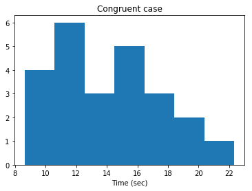

```python
plt.hist(data['Congruent'],bins=7)  # arguments are passed to np.histogram
plt.title("Congruent case")
plt.xlabel('Time (sec)')
plt.show()
```

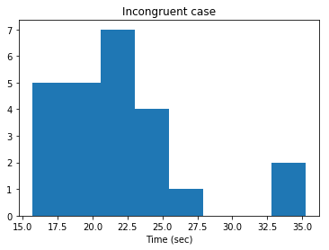

```python
plt.hist(data['Incongruent'], bins=8)  # arguments are passed to np.histogram
plt.title("Incongruent case")
plt.xlabel('Time (sec)')
plt.show()
```

#### 5 . Now, perform the statistical test and report your results. What is your confidence level and your critical statistic value? Do you reject the null hypothesis or fail to reject it? Come to a conclusion in terms of the experiment task. Did the results match up with your expectations?

A: We observe that,

alpha = 0.05 Confidence Interval = 95%

From t-table, t_critical = 2.069 / -2.069

Hence, I reject the null hypothesis, H_null.

The difference between the means of both cases was about 57%, which indicate two different distributions. This is further boosted by the t-test. The result matched up with my expectations.

```python
# Means
print('Congruent Mean - ',data.Congruent.mean())
print('Incongruent Mean - ',data.Incongruent.mean())

# Point Estimate
point_estimate = data.Congruent.mean()-data.Incongruent.mean()
print('Point Estimate -',point_estimate)

# Average Difference
data['Differences'] = data.Congruent - data.Incongruent
print('Average Difference -',data.Differences.mean())

# Count
count = data.Congruent.count()
print('Count -',count)

# Degrees of Freedom
dof = count - 1
print('Degrees of Freedom - ', dof)

# Standard Diviation of Differneces
std = data.Differences.std()
print('Standard Diviation of Differences - ', std)

# t-Statistic
t_statistic = point_estimate / (std / (count**0.5))
print('t-statistic', t_statistic)

# Test
print('Test: t_statistic < t_critical: {}'.format(t_statistic < -2.069))
print('Test: t_statistic > t_critical: {}'.format(t_statistic > 2.069))
```

```
('Congruent Mean - ', 14.051124999999999)
('Incongruent Mean - ', 22.015916666666666)
('Point Estimate -', -7.9647916666666667)
('Average Difference -', -7.9647916666666658)
('Count -', 24)
('Degrees of Freedom - ', 23)
('Standard Diviation of Differences - ', 4.8648269103590556)
('t-statistic', -8.020706944109957)
Test: t_statistic < t_critical: True
Test: t_statistic > t_critical: False
```

#### Bibliography -

1. https://en.wikipedia.org/wiki/Stroop_effect
2. https://pandas.pydata.org/pandas-docs/stable/generated/pandas.DataFrame.describe.html
3. https://docs.scipy.org/doc/numpy-1.13.0/reference/generated/numpy.histogram.html
4. https://s3.amazonaws.com/udacity-hosted-downloads/t-table.jpg